# GenderML (gender classification project)

Gender classification is a classic problem in machine learning. This project will consist on a classification of images, via a model that will be developed. At the end of the project, the model should predict the gender of a person face

The dataset has been downloaded from Kaggle Dataset, then hosted on Gdrive.. The dataset contains two folders namely Training and Validation for training and validating the model, so the data processing part is mostly sorted/done, apart from resizing. The model will be trained using the techniques learned at the couse: Deep Learning with PyTorch: Zero to GANs.

## Importing libraries required on the project

```python
import os
import pandas as pd
import numpy as np
import matplotlib.pyplot as plt
import torch
import torch.nn as nn
import torch.nn.functional as F
import torchvision
import torchvision.transforms as transforms
import seaborn as sns
from torchvision.datasets.utils import download_url
from torch.utils.data import random_split
from google.colab import drive #This allows to import the dataset from Google Drive
from torchvision.datasets import ImageFolder
from torchvision.transforms import ToTensor
from torch.utils.data.dataloader import DataLoader
from torchvision.utils import make_grid

%matplotlib inline
```

## Dataset

As state before, we will use a dataset containind thousands of images of people's face. These images will then be thrown into a ML model to sort them by gender.

### Accessing the dataset

```python
drive.mount('/content/gdrive')
```

```python
data_dir = './gdrive/MyDrive/genderML/' # Path to dataset in gdrive

print(os.listdir(data_dir)) # Print folders in dataset
classes = os.listdir(data_dir + '/Training/') # List the image Classes
print(classes)
```

```
['Training', 'Validation']
['male', 'female']
```

It's interesting to see the quantity of images we will be working with.

```python
count = []
for folder in classes:
    num_images = len(os.listdir(data_dir + '/Training/' + folder))
    count.append(num_images)
    print(f'There are {num_images} images in the {folder} category.')
```

```
There are 23766 images in the male category.
There are 23242 images in the female category.
```

Plotting the result to have a more intuitive idea of the dataset we imported.

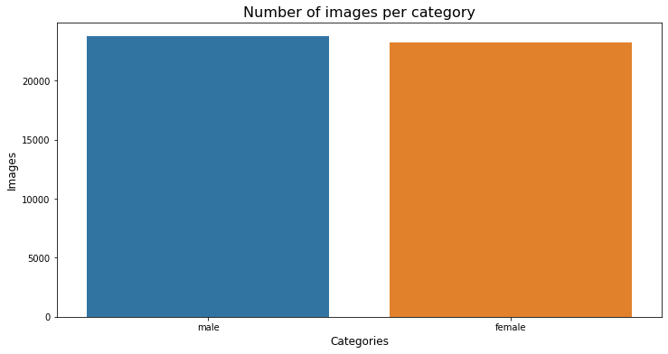

```python
plt.figure(figsize=(12, 6))
sns.barplot(x=classes, y=count)
plt.title('Number of images per category', size=16)
plt.ylabel('Images', size=12)
plt.xlabel('Categories', size=12)
plt.show;
```

Selecting CUDA to improve the time spent running the model.

```python
device = torch.device("cuda:0"
                      if torch.cuda.is_available()
                      else "cpu")
print(device)
```

```
cuda:0
```

Resizing the images to store the data in tensors

```python
transform = transforms.Compose([transforms.Resize((100, 100)), transforms.ToTensor()])
```

```python
dataset_train = ImageFolder(data_dir+"/Training", transform = transform)
dataset_val = ImageFolder(data_dir+"/Validation", transform = transform)
```

Let's check some samples to see if the images' size is uniform now

```python
im_count = 0
for image,_ in dataset_train:
  im_count += 1
  print(image.shape)
  if im_count == 15:
    break
```

```
torch.Size([3, 100, 100])
torch.Size([3, 100, 100])
torch.Size([3, 100, 100])
torch.Size([3, 100, 100])
torch.Size([3, 100, 100])
torch.Size([3, 100, 100])
torch.Size([3, 100, 100])
torch.Size([3, 100, 100])
torch.Size([3, 100, 100])
torch.Size([3, 100, 100])
torch.Size([3, 100, 100])
torch.Size([3, 100, 100])
torch.Size([3, 100, 100])
torch.Size([3, 100, 100])
torch.Size([3, 100, 100])
```

### Plotting a sample image

```python
def show_example(img,label):
  print('Label: ', classes[label], '('+str(label)+')')
  plt.imshow(img.permute(1, 2, 0))
```

```
Label:  female (1)
```

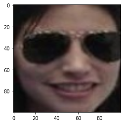

```python
show_example(*dataset_train[25000])
```

```python
jovian.commit(project='04-mlcourse-proyecto')
```

```
[jovian] Detected Colab notebook...
[jovian] Uploading colab notebook to Jovian...
[jovian] Capturing environment..
[jovian] Committed successfully! https://jovian.ai/pascualete12/04-mlcourse-proyecto
```

```
'https://jovian.ai/pascualete12/04-mlcourse-proyecto'
```

# Training section

Defining the train size, seed and checking the size of the traning & validation data

```python
train_size = 45000
val_size = len(dataset_train) - train_size

random_seed = 0
torch.manual_seed(random_seed)
data_train, data_val = random_split(dataset_train, [train_size, val_size])
len(data_train), len(data_val)
```

```
(45000, 2008)
```

Batch size (the bigger, the better in this case)

```python
batch_size = 256
```

```python
train_dl = DataLoader(data_train, batch_size, shuffle = True, num_workers= 4, pin_memory=True)
val_dl = DataLoader(data_val, batch_size, num_workers=4, pin_memory=True)
test_dl = DataLoader(dataset_val, batch_size, num_workers=4, pin_memory=True)
```

Sample batch

```python
def show_batch(dl):
  for img, label in dl:
    fig, ax = plt.subplots(figsize = (16, 12))
    ax.set_xticks([]); ax.set_yticks([])
    ax.imshow(make_grid(img, nrow = 16).permute(1,2,0))
    break
```

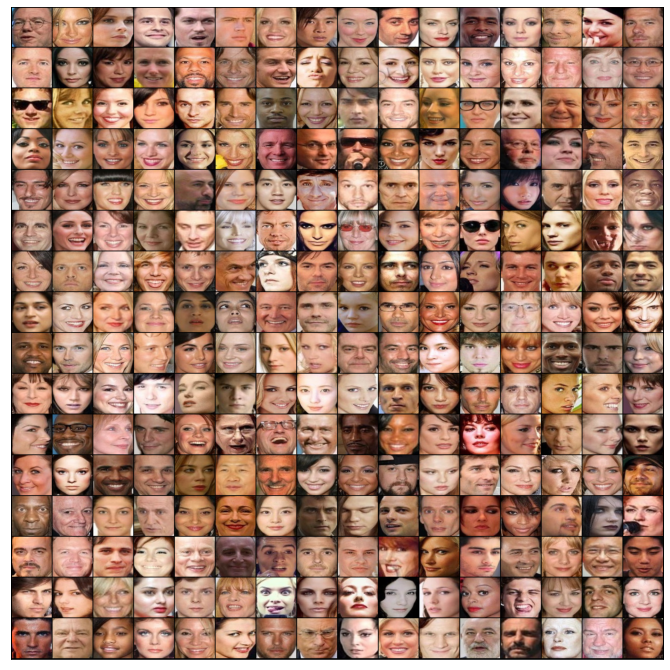

```python
show_batch(train_dl)
```

# Model training.

```python
class ImageClassificationBase(nn.Module):
    def training_step(self, batch):
        images, labels = batch
        out = self(images)                  # Generate predictions
        loss = F.cross_entropy(out, labels) # Calculate loss
        return loss

    def validation_step(self, batch):
        images, labels = batch
        out = self(images)                    # Generate predictions
        loss = F.cross_entropy(out, labels)   # Calculate loss
        acc = accuracy(out, labels)           # Calculate accuracy
        return {'val_loss': loss.detach(), 'val_acc': acc}

    def validation_epoch_end(self, outputs):
        batch_losses = [x['val_loss'] for x in outputs]
        epoch_loss = torch.stack(batch_losses).mean()   # Combine losses
        batch_accs = [x['val_acc'] for x in outputs]
        epoch_acc = torch.stack(batch_accs).mean()      # Combine accuracies
        return {'val_loss': epoch_loss.item(), 'val_acc': epoch_acc.item()}

    def epoch_end(self, epoch, result):
        print("Epoch [{}], train_loss: {:.4f}, val_loss: {:.4f}, val_acc: {:.4f}".format(
            epoch, result['train_loss'], result['val_loss'], result['val_acc']))

def accuracy(outputs, labels):
    _, preds = torch.max(outputs, dim=1)
    return torch.tensor(torch.sum(preds == labels).item() / len(preds))
```

```python
class GenCnnModel(ImageClassificationBase):
    def __init__(self):
        super().__init__()
        self.network = nn.Sequential(
            nn.Conv2d(3, 32, kernel_size=3, padding=1),
            nn.ReLU(),
            nn.Conv2d(32, 64, kernel_size=3,stride=1, padding=1),
            nn.ReLU(),
            nn.MaxPool2d(2, 2),  # Output size: 64 x 50 x 50

            nn.Conv2d(64, 128, kernel_size=3, padding=1),
            nn.ReLU(),
            nn.Conv2d(128, 128, kernel_size=3,stride=1, padding=1),
            nn.ReLU(),
            nn.MaxPool2d(2, 2),  # Output size: 128 x 25 x 25

            nn.Conv2d(128, 256, kernel_size=3, padding=1),
            nn.ReLU(),
            nn.Conv2d(256, 256, kernel_size=3,stride=1, padding=1),
            nn.ReLU(),
            nn.MaxPool2d(2, 2),  # Output size: 256 x 12 x 12

            nn.Conv2d(256, 512, kernel_size=3, padding=1),
            nn.ReLU(),
            nn.Conv2d(512, 512, kernel_size=3,stride=1, padding=1),
            nn.ReLU(),
            nn.MaxPool2d(2, 2),  # Output size: 512 x 6 x 6

            nn.Flatten(),
            nn.Linear(512*6*6, 2048),
            nn.ReLU(),
            nn.Linear(2048, 1024),
            nn.ReLU(),
            nn.Linear(1024, 512),
            nn.ReLU(),
            nn.Linear(512, 128),
            nn.ReLU(),
            nn.Linear(128, 32),
            nn.ReLU(),
            nn.Linear(32, 2))

    def forward(self, xb):
        return self.network(xb)
```

```python
model = GenCnnModel()
model
```

```
GenCnnModel(
  (network): Sequential(
    (0): Conv2d(3, 32, kernel_size=(3, 3), stride=(1, 1), padding=(1, 1))
    (1): ReLU()
    (2): Conv2d(32, 64, kernel_size=(3, 3), stride=(1, 1), padding=(1, 1))
    (3): ReLU()
    (4): MaxPool2d(kernel_size=2, stride=2, padding=0, dilation=1, ceil_mode=False)
    (5): Conv2d(64, 128, kernel_size=(3, 3), stride=(1, 1), padding=(1, 1))
    (6): ReLU()
    (7): Conv2d(128, 128, kernel_size=(3, 3), stride=(1, 1), padding=(1, 1))
    (8): ReLU()
    (9): MaxPool2d(kernel_size=2, stride=2, padding=0, dilation=1, ceil_mode=False)
    (10): Conv2d(128, 256, kernel_size=(3, 3), stride=(1, 1), padding=(1, 1))
    (11): ReLU()
    (12): Conv2d(256, 256, kernel_size=(3, 3), stride=(1, 1), padding=(1, 1))
    (13): ReLU()
    (14): MaxPool2d(kernel_size=2, stride=2, padding=0, dilation=1, ceil_mode=False)
    (15): Conv2d(256, 512, kernel_size=(3, 3), stride=(1, 1), padding=(1, 1))
    (16): ReLU()
    (17): Conv2d(512, 512, kernel_size=(3, 3), stride=(1, 1), padding=(1, 1))
    (18): ReLU()
    (19): MaxPool2d(kernel_size=2, stride=2, padding=0, dilation=1, ceil_mode=False)
    (20): Flatten(start_dim=1, end_dim=-1)
    (21): Linear(in_features=18432, out_features=2048, bias=True)
    (22): ReLU()
    (23): Linear(in_features=2048, out_features=1024, bias=True)
    (24): ReLU()
    (25): Linear(in_features=1024, out_features=512, bias=True)
    (26): ReLU()
    (27): Linear(in_features=512, out_features=128, bias=True)
    (28): ReLU()
    (29): Linear(in_features=128, out_features=32, bias=True)
    (30): ReLU()
    (31): Linear(in_features=32, out_features=2, bias=True)
  )
)
```

```python
for images, labels in train_dl:
    print("images shape: ", images.shape)
    out = model(images)
    print("out shape: ", out.shape)
    print("out[0]: ", out[0])
    break
```

```
images shape:  torch.Size([256, 3, 100, 100])
out shape:  torch.Size([256, 2])
out[0]:  tensor([-0.0278, -0.1568], grad_fn=<SelectBackward>)
```

Recheck cuda status availability

```python
device = torch.device("cuda" if torch.cuda.is_available()
                                  else "cpu")
device
```

```
device(type='cuda')
```

```python
def to_device(data, device):
    """Move tensor(s) to chosen device"""
    if isinstance(data, (list,tuple)):
        return [to_device(x, device) for x in data]
    return data.to(device, non_blocking=True)

class DeviceDataLoader():
    """Wrap a dataloader to move data to a device"""
    def __init__(self, dl, device):
        self.dl = dl
        self.device = device

    def __iter__(self):
        """Yield a batch of data after moving it to device"""
        for b in self.dl:
            yield to_device(b, self.device)

    def __len__(self):
        """Number of batches"""
        return len(self.dl)
```

```python
train_loader = DeviceDataLoader(train_dl, device)
val_loader = DeviceDataLoader(val_dl, device)
test_loader = DeviceDataLoader(test_dl, device)
to_device(model, device);
```

Once the data is dumped to GPU, we procceed with the training

```python
@torch.no_grad()
def evaluate(model, val_loader):
    model.eval()
    outputs = [model.validation_step(batch) for batch in val_loader]
    return model.validation_epoch_end(outputs)

def fit(epochs, lr, model, train_loader, val_loader, opt_func=torch.optim.SGD):
    history = []
    optimizer = opt_func(model.parameters(), lr)
    for epoch in range(epochs):
        # Training Phase
        model.train()
        train_losses = []
        for batch in train_loader:
            loss = model.training_step(batch)
            train_losses.append(loss)
            loss.backward()
            optimizer.step()
            optimizer.zero_grad()
        # Validation phase
        result = evaluate(model, val_loader)
        result['train_loss'] = torch.stack(train_losses).mean().item()
        model.epoch_end(epoch, result)
        history.append(result)
    return history
```

```python
model = to_device(GenCnnModel(), device)
```

```python
model
```

```
GenCnnModel(
  (network): Sequential(
    (0): Conv2d(3, 32, kernel_size=(3, 3), stride=(1, 1), padding=(1, 1))
    (1): ReLU()
    (2): Conv2d(32, 64, kernel_size=(3, 3), stride=(1, 1), padding=(1, 1))
    (3): ReLU()
    (4): MaxPool2d(kernel_size=2, stride=2, padding=0, dilation=1, ceil_mode=False)
    (5): Conv2d(64, 128, kernel_size=(3, 3), stride=(1, 1), padding=(1, 1))
    (6): ReLU()
    (7): Conv2d(128, 128, kernel_size=(3, 3), stride=(1, 1), padding=(1, 1))
    (8): ReLU()
    (9): MaxPool2d(kernel_size=2, stride=2, padding=0, dilation=1, ceil_mode=False)
    (10): Conv2d(128, 256, kernel_size=(3, 3), stride=(1, 1), padding=(1, 1))
    (11): ReLU()
    (12): Conv2d(256, 256, kernel_size=(3, 3), stride=(1, 1), padding=(1, 1))
    (13): ReLU()
    (14): MaxPool2d(kernel_size=2, stride=2, padding=0, dilation=1, ceil_mode=False)
    (15): Conv2d(256, 512, kernel_size=(3, 3), stride=(1, 1), padding=(1, 1))
    (16): ReLU()
    (17): Conv2d(512, 512, kernel_size=(3, 3), stride=(1, 1), padding=(1, 1))
    (18): ReLU()
    (19): MaxPool2d(kernel_size=2, stride=2, padding=0, dilation=1, ceil_mode=False)
    (20): Flatten(start_dim=1, end_dim=-1)
    (21): Linear(in_features=18432, out_features=2048, bias=True)
    (22): ReLU()
    (23): Linear(in_features=2048, out_features=1024, bias=True)
    (24): ReLU()
    (25): Linear(in_features=1024, out_features=512, bias=True)
    (26): ReLU()
    (27): Linear(in_features=512, out_features=128, bias=True)
    (28): ReLU()
    (29): Linear(in_features=128, out_features=32, bias=True)
    (30): ReLU()
    (31): Linear(in_features=32, out_features=2, bias=True)
  )
)
```

```python
evaluate(model, val_loader)
```

```
{'val_acc': 0.5050152540206909, 'val_loss': 0.6933099627494812}
```

We got near 50% accuracy on our model, let's do the proper iteration studied in this course to raise it even further.

```python
num_epochs = 10
opt_func = torch.optim.Adam
lr = 0.001
```

Saving the parameters in jovian

```python
jovian.reset()
jovian.log_hyperparams({
    'num_epochs': num_epochs,
    'opt_func': opt_func.__name__,
    'batch_size': batch_size,
    'lr': lr,
})
```

```
[jovian] Hyperparams logged.
```

```python
history = fit(num_epochs, lr, model, train_loader, val_loader, opt_func)
```

```
Epoch [0], train_loss: 0.6720, val_loss: 0.6619, val_acc: 0.6968
Epoch [1], train_loss: 0.3085, val_loss: 0.1889, val_acc: 0.9315
Epoch [2], train_loss: 0.1571, val_loss: 0.1611, val_acc: 0.9421
Epoch [3], train_loss: 0.1320, val_loss: 0.1431, val_acc: 0.9471
Epoch [4], train_loss: 0.1176, val_loss: 0.1383, val_acc: 0.9477
Epoch [5], train_loss: 0.1068, val_loss: 0.1507, val_acc: 0.9507
Epoch [6], train_loss: 0.0965, val_loss: 0.1493, val_acc: 0.9516
Epoch [7], train_loss: 0.0878, val_loss: 0.1444, val_acc: 0.9521
Epoch [8], train_loss: 0.0804, val_loss: 0.1351, val_acc: 0.9522
Epoch [9], train_loss: 0.0778, val_loss: 0.1448, val_acc: 0.9477
```

Log the metrics

```python
jovian.log_metrics(train_loss=history[-1]['train_loss'], val_loss=history[-1]['val_loss'], val_acc=history[-1]['val_acc'])
```

```
[jovian] Metrics logged.
```

Plots

```python
def plot_accuracies(history):
    accuracies = [x['val_acc'] for x in history]
    plt.plot(accuracies, '-x')
    plt.xlabel('Epoch')
    plt.ylabel('Accuracy')
    plt.title('Accuracy vs. No. of epochs');
```

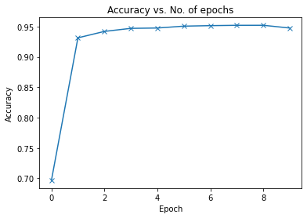

```python
plot_accuracies(history)
```

```python
def plot_losses(history):
    train_losses = [x.get('train_loss') for x in history]
    val_losses = [x['val_loss'] for x in history]
    plt.plot(train_losses, '-bx')
    plt.plot(val_losses, '-rx')
    plt.xlabel('Epoch')
    plt.ylabel('Loss')
    plt.legend(['Training', 'Validation'])
    plt.title('Loss vs. No. of epochs');
```

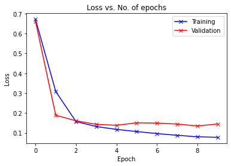

```python
plot_losses(history)
```

Saving the final metrics

```python
result = evaluate(model, test_loader)
result
jovian.log_metrics(test_loss=result['val_loss'], test_acc=result['val_acc'])
```

[output not shown]

Extra section to try other hyperparameters

```python
num_epochs = 5
opt_func = torch.optim.Adam
lr = 0.005
```

```python
history = fit(num_epochs, lr, model, train_loader, val_loader, opt_func)
```

[output not shown]

## Conclusions - summarize your learning & identify opportunities

The model used in this project can be easily adapted to other datasets, it would be interesting to expand the model to analyze images with multiple people/faces in them.

```python
jovian.commit(project='04-mlcourse-proyecto')
```

```
[jovian] Detected Colab notebook...
[jovian] Uploading colab notebook to Jovian...
[jovian] Capturing environment..
[jovian] Committed successfully! https://jovian.ai/pascualete12/04-mlcourse-proyecto
```

```
'https://jovian.ai/pascualete12/04-mlcourse-proyecto'
```